# Notebook report

## Report for Simulation Video #2

Suppose the simulation discussed in Video #1 was used to get a better understanding of daily total handling time. To develop insights into 5-day total handling time, I could re-run the simulation 5 times. This can be done easily by using the functionality available in the *Repeat* tab

I selected “call” and “time” as variables to re-simulate, and select the variable of interest “total_time” in the *Output variables* box. In this example I want to determine the sum of simulated daily total handling time across 5 repetitions, so I select *Simulation* in the *Group by* box and *sum* in the *Apply function* box. The result shows that probability that the total handling time for five days is greater than 4,500 mins is 16.56%.

Note that the variable used in the formula is `total_time_sum`, i.e., the sum of the `total_time` variable across 5 repeated simulations.

```r
repdat <- repeater(
  simdat,
  nr = 5,
  vars = c("time", "call"),
  sum_vars = "total_time",
  form = "total_time_4500 = total_time_sum > 4500",
  seed = 1234
)
summary(repdat, dec = 4)
```

```
Repeated simulation
Simulations   : 5,000
Repetitions   : 5
Re-simulated  : time, call
Group by      : Simulation
Function      : sum
Random  seed  : 1234
Simulated data: simdat
Repeat data   : repdat
Formulas      :
    total_time_4500 = total_time_sum > 4500

Variables:
       variable n_obs       mean       sd        min        p25     median        p75        max
 total_time_sum 5,000 3,988.5154 531.8581 2,057.8685 3,626.7481 3,981.2056 4,333.1187 6,057.3499

Logicals:
                TRUE (nr)   TRUE (prop)
total_time_4500         828      0.1656
```

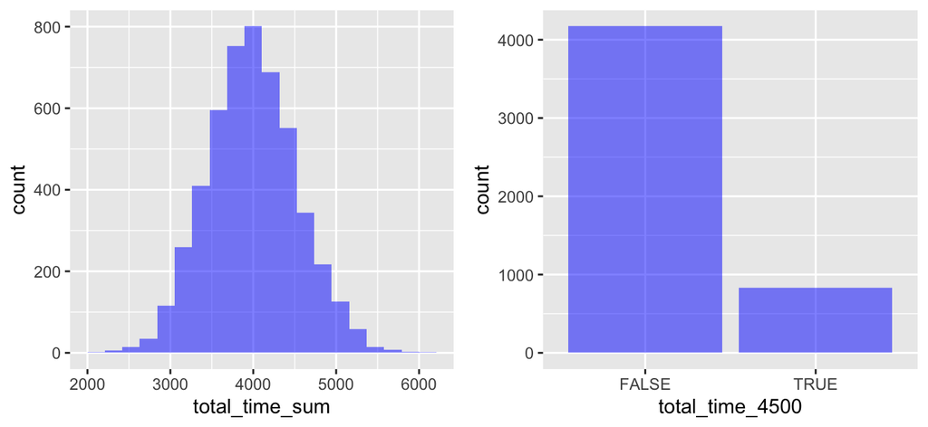

```r
plot(repdat, custom = FALSE)
```

```r
register("repdat")
```

For this question, you could also 5 separate random variables in the simulate tab that capture total handling time and the sum them up. However, if I would like to study the annual total handling time over 365 days, this strategy will not scale.

For example, I would like to study the probability that the annual total handling time will exceed 300,000 mins. In the Repeat tab, all I need to do is to change the number of replications to 365, update the formula, and click *Repeat Simulation*. Within a couple of seconds, I get the result 3.9%. In a nutshell, learning the repeat tool can save you a lot of time!

```r
repdat_365 <- repeater(
  simdat,
  nr = 365,
  vars = c("time", "call"),
  sum_vars = "total_time",
  form = c(
    "total_time_300000 = total_time_sum > 300000"
  ),
  seed = 1234
)
summary(repdat_365, dec = 4)
```

```
Repeated simulation
Simulations   : 5,000
Repetitions   : 365
Re-simulated  : time, call
Group by      : Simulation
Function      : sum
Random  seed  : 1234
Simulated data: simdat
Repeat data   : repdat_365
Formulas      :
    total_time_300000 = total_time_sum > 300000

Variables:
       variable n_obs         mean         sd          min          p25       median          p75          max
 total_time_sum 5,000 291,940.7762 4,554.1736 271,947.0472 288,797.3160 291,910.7397 294,965.7267 310,873.4944

Logicals:
                  TRUE (nr)   TRUE (prop)
total_time_300000         195       0.039
```

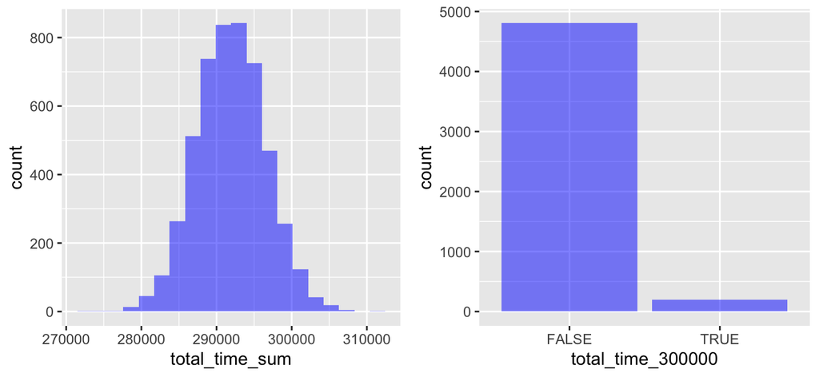

```r
plot(repdat_365, custom = FALSE)
```

```r
register("repdat_365")
```